# RNA-seq analysis in R

Gene Set Testing for RNA-seq - Solutions

Stephane Ballereau, Mark Dunning, Oscar Rueda, Ashley Sawle

Last modified: 23 Jul 2018

## Challenge 1

> Another common way to rank the genes is to order by pvalue, but also, sorting so that upregulated genes are at start and downregulated at the other - you can do this combining the sign of the fold change and the pvalue. 1. Rank the genes by statisical significance - you will need to create a new ranking value using `-log10({p value}) * sign({Fold Change})` 2. Load the “C2” pathways from the the `data/mouse_c2_v5.RData` file 3. Run `fgsea` using the new ranked genes and the C2 pathways 4. Run `fgsea` using the new ranked genes and the H pathways. How do these results differ from the ones we got when ranking by the fold change alone?

```r
ranks <- -log10(gseaDat$pvalue) * sign(gseaDat$logFC)
names(ranks) <- gseaDat$Entrez
load("../Robjects/mouse_c2_v5.RData")
pathwaysC2 <- Mm.c2
fgseaResC2 <- fgsea(pathwaysC2, ranks, minSize=15, maxSize = 500, nperm=1000)
```

```
There are ties in the preranked stats (0.04% of the list).
The order of those tied genes will be arbitrary, which may produce unexpected results.
```

```r
head(fgseaResC2[order(padj, -abs(NES)), ], n=10)
```

| pathway | pval | padj | ES | NES | nMoreExtreme | size | leadingEdge |
| --- | --- | --- | --- | --- | --- | --- | --- |
| REACTOME_NONSENSE_MEDIATED_DECAY_ENHANCED_BY_THE_EXON_JUNCTION_COMPLEX | 0.002074689 | 0.03941969 | -0.8840484 | -2.671637 | 0 | 98 |  |
| REACTOME_INFLUENZA_LIFE_CYCLE | 0.002173913 | 0.03941969 | -0.8571039 | -2.668977 | 0 | 124 |  |
| REACTOME_3_UTR_MEDIATED_TRANSLATIONAL_REGULATION | 0.002074689 | 0.03941969 | -0.8820138 | -2.665489 | 0 | 98 |  |
| REACTOME_INFLUENZA_VIRAL_RNA_TRANSCRIPTION_AND_REPLICATION | 0.002040816 | 0.03941969 | -0.8805708 | -2.650337 | 0 | 93 |  |
| REACTOME_PEPTIDE_CHAIN_ELONGATION | 0.002132196 | 0.03941969 | -0.9053417 | -2.635444 | 0 | 77 |  |
| KEGG_RIBOSOME | 0.002150538 | 0.03941969 | -0.8943063 | -2.608795 | 0 | 79 |  |
| REACTOME_SRP_DEPENDENT_COTRANSLATIONAL_PROTEIN_TARGETING_TO_MEMBRANE | 0.002066116 | 0.03941969 | -0.8484059 | -2.574305 | 0 | 100 |  |
| REACTOME_TRANSLATION | 0.002150538 | 0.03941969 | -0.8034879 | -2.549090 | 0 | 138 |  |
| REACTOME_METABOLISM_OF_MRNA | 0.002109705 | 0.03941969 | -0.7731403 | -2.541241 | 0 | 200 |  |
| REACTOME_METABOLISM_OF_RNA | 0.002092050 | 0.03941969 | -0.7511378 | -2.527457 | 0 | 240 |  |

```r
fgseaResH <- fgsea(pathwaysH, ranks, minSize=15, maxSize = 500, nperm=1000)
```

```
There are ties in the preranked stats (0.04% of the list).
The order of those tied genes will be arbitrary, which may produce unexpected results.
```

```r
head(fgseaResH[order(padj, -abs(NES)), ], n=20)
```

| pathway | pval | padj | ES | NES | nMoreExtreme | size | leadingEdge |
| --- | --- | --- | --- | --- | --- | --- | --- |
| HALLMARK_MYC_TARGETS_V1 | 0.002070393 | 0.008716876 | -0.6804876 | -2.251637 | 0 | 200 |  |
| HALLMARK_OXIDATIVE_PHOSPHORYLATION | 0.001956947 | 0.008716876 | 0.6447992 | 2.086281 | 0 | 197 |  |
| HALLMARK_TGF_BETA_SIGNALING | 0.002057613 | 0.008716876 | -0.7398642 | -2.022466 | 0 | 53 |  |
| HALLMARK_CHOLESTEROL_HOMEOSTASIS | 0.001972387 | 0.008716876 | 0.7030666 | 1.972914 | 0 | 72 |  |
| HALLMARK_MYC_TARGETS_V2 | 0.002092050 | 0.008716876 | -0.6998738 | -1.943492 | 0 | 58 |  |
| HALLMARK_E2F_TARGETS | 0.002053388 | 0.008716876 | -0.5641934 | -1.871610 | 0 | 201 |  |
| HALLMARK_FATTY_ACID_METABOLISM | 0.001941748 | 0.008716876 | 0.5787744 | 1.822968 | 0 | 154 |  |
| HALLMARK_ADIPOGENESIS | 0.001930502 | 0.008716876 | 0.5613190 | 1.821899 | 0 | 199 |  |
| HALLMARK_MTORC1_SIGNALING | 0.001941748 | 0.008716876 | 0.5399481 | 1.753761 | 0 | 201 |  |
| HALLMARK_PEROXISOME | 0.001941748 | 0.008716876 | 0.5922516 | 1.734446 | 0 | 96 |  |

[output cut: 10 more lines]

## Challenge 2

> 1. Create a gene list for genes that are up-regulated by at least 4x (logFC>2) in lactating mice
> 2. Run a `goseq` analysis on this gene list
> 3. Plot the results
> 4. How is this result different to the previous GO analysis?

Look at genes that are up regulated by at least 4x (logFC>2) in lactating mices

```
initial point very close to some inequality constraints
```

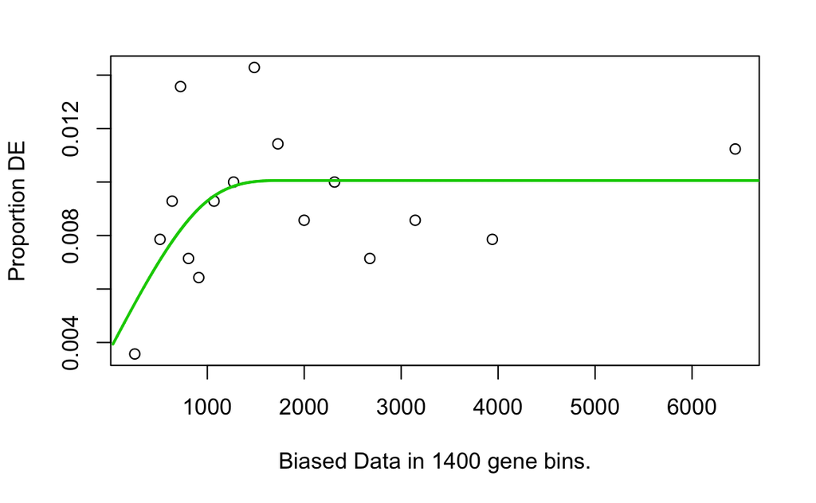

```r
isSigGeneUp <- shrinkLvV$FDR < 0.01 &
    !is.na(shrinkLvV$FDR) &
    shrinkLvV$logFC > 2
genesUp <- as.integer(isSigGeneUp)
names(genesUp) <- shrinkLvV$GeneID
pwf <- nullp(genesUp, "mm10", "ensGene", bias.data = shrinkLvV$medianTxLength)
```

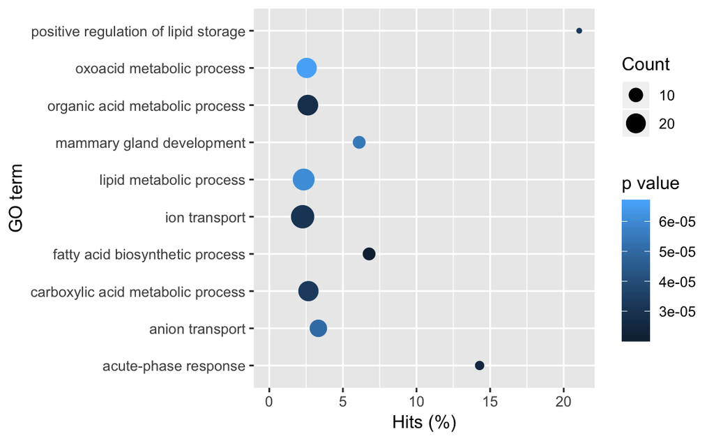

```r
goResultsUp <- goseq(pwf, "mm10","ensGene", test.cats=c("GO:BP"))
goResultsUp %>%
    top_n(10, wt=-over_represented_pvalue) %>%
    mutate(hitsPerc=numDEInCat*100/numInCat) %>%
    ggplot(aes(x=hitsPerc,
               y=term,
               colour=over_represented_pvalue,
               size=numDEInCat)) +
        geom_point() +
        expand_limits(x=0) +
        labs(x="Hits (%)", y="GO term", colour="p value", size="Count")
```

## Challenge 3

> 1. Use `pathview` to export a figure for “mmu04060”, but this time only use genes that are statistically significant at FDR < 0.01

```r
sigGenes <- shrinkLvV$FDR < 0.01 & !is.na(shrinkLvV$FDR)
logFC <- annotLvV$logFC[sigGenes]
names(logFC) <- annotLvV$Entrez[sigGenes]
pathview(gene.data = logFC,
         pathway.id = "mmu04060",
         species = "mmu",
         limit = list(gene=5, cpd=1))
```

```
Info: Downloading xml files for mmu04060, 1/1 pathways..
Info: Downloading png files for mmu04060, 1/1 pathways..
Info: Working in directory /Users/sawle01/Documents/RNAseq_course/CRUK_CI_RNAseq_course/Course_Materials/solutions
Info: Writing image file mmu04060.pathview.png
```

mmu04060.pathview.png:

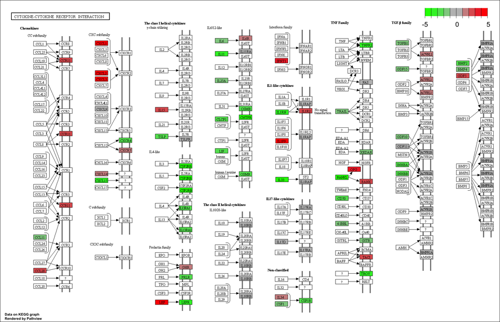

mmu04060 -Cytokine-cytokine receptor interaction